# West Windsor-Plainsboro Regional School District — NJ School Data Almanac – NJ District Profiles

NJ School Data Almanac

West Windsor-Plainsboro Regional School District

MERCER COUNTY · TRADITIONAL PUBLIC DISTRICT · DFG J · 8,708 STUDENTS (2026)

8,708

Students

96.5%

4-yr grad rate

74%

Gr 3-8 ELA

8.6%

Chronically absent

$17,792

Per pupil

*10 things the data says about West Windsor-Plainsboro Regional School District. Every figure is computed from New Jersey Department of Education data via the njschooldata package — nothing is estimated. Comparisons use District Factor Group (DFG) peers (25 districts in DFG J).*

No. 1 ACHIEVEMENT

## West Windsor-Plainsboro’s Reading Scores Never Recovered: 74.0% Proficient in 2024, Below Even the COVID Trough

Grades 3-8 ELA proficiency fell to 74.0% in 2024, lower than the 75.5% recorded in the depths of pandemic disruption two years earlier.

Math followed the more familiar shape but has not closed the gap either. Proficiency held at 75.1% in both 2017 and 2019, dropped sharply to 64.9% in 2022, and has clawed back only to 66.9% in 2023 and 67.4% in 2024 — still more than seven points below where it sat before the pandemic.

This is a district where 64.0% of high schoolers pass an AP or IB exam and graduation tops 96%, which makes a multi-year erosion in elementary and middle-school reading especially notable: the youngest students are the furthest from a rebound. The question the trend raises is whether 74.0% represents a new floor or the bottom of a decline that has not yet stopped.

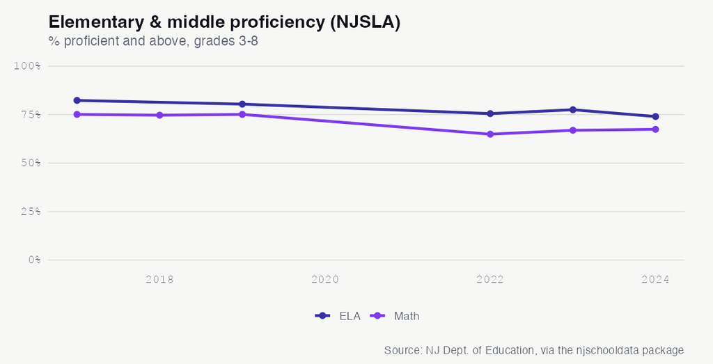

See the underlying data ›

No. 2 ACHIEVEMENT

## In a Heavily Asian-American District, White Students Trail by 25 Points on Grades 3-8 Reading

On the 2024 NJSLA ELA exam, 81.5% of Asian students scored proficient versus 56.4% of white students — a 25-point gap inside one district.

West Windsor-Plainsboro is one of New Jersey’s most heavily Asian-American districts, and its 2024 reading data shows just how much that group drives the headline numbers. On the NJSLA ELA exam for grades 3 through 8, 81.5% of students who are Asian scored proficient, well above the district-wide 74.0%. Students who are white scored 56.4% — a gap of 25 percentage points within the same schools, and an unusual reversal of the pattern seen in most New Jersey districts.

The gaps widen further down the list. Students who are Hispanic scored 41.8% proficient and students who are Black 36.8%, while students who are economically disadvantaged scored 30.3% and students who receive special education services scored 19.4%. Among multilingual learners the split is stark: former English learners reached 64.3% while current English learners registered 0.0%.

These subgroup numbers sit beneath a district-wide figure that looks strong, illustrating how a large, high-scoring majority can mask wide internal disparities. What the data cannot answer is whether the district’s instructional model is built around the strengths of its largest group at the expense of the smaller ones.

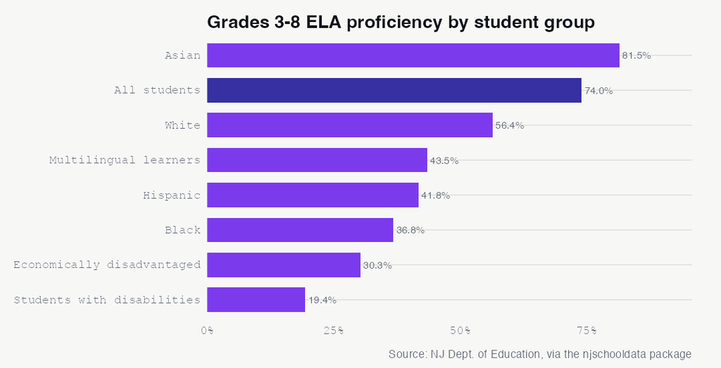

See the underlying data ›

No. 3 DEMOGRAPHICS

## West Windsor-Plainsboro’s White Enrollment Share Fell From 26.7% to 11.8% Since 2015

Over 11 years the district’s white share more than halved while its Asian share, already a majority, climbed to 71.9%.

West Windsor-Plainsboro entered 2015 as one of New Jersey’s most heavily Asian-American districts, and it has only grown more so. The share of students who are white fell from 26.7% in 2015 to 11.8% in 2026, a drop of 14.9 percentage points and the single largest demographic change in the district over that span. The share of students who are Asian rose from 61.9% to 71.9%, a gain of about 10 percentage points from an already-dominant base.

The other moving piece is students who identify as multiracial, whose share climbed from 1.1% in 2015 to 4.7% in 2026. Students who are Black and Hispanic stayed comparatively flat, with the Black share near 5% and the Hispanic share rising modestly to 6.0% by 2026.

These shifts unfolded as total enrollment shrank, so they reflect changes in who is staying and arriving, not just raw counts. What the demographic data cannot say is how the families behind these trends — and the programs built for them — will reshape the district over the next decade.

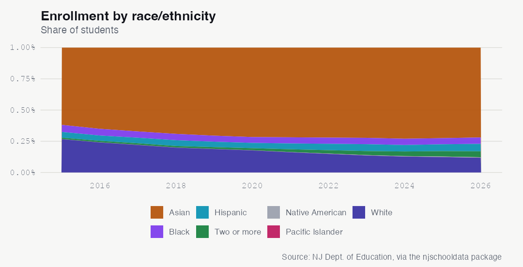

See the underlying data ›

No. 4 FINANCE

The district’s per-pupil spending sits in the 8th percentile of its District Factor Group J peer group, roughly $3,400 below the peer median.

Among New Jersey’s wealthiest districts, high spending is common — but West Windsor-Plainsboro is not one of the big spenders. In 2024 the district spent $17,792 per pupil, which placed it in the 8th percentile of its 25-district District Factor Group J peer group. The peer median was $21,237, leaving the district roughly $3,400 per student below the middle of its group.

That relative thrift coexists with one of the largest student bodies in the group. Spending has grown 38.6% since 2014, when per-pupil cost was $12,833, but average daily enrollment has fallen over the same period, from 9,719 to 8,948, so rising totals are spread across fewer students. Of every dollar spent in 2025, 59.4% went to classroom instruction and 9.7% to administration, with a student-to-administrator ratio of 174 to 1.

The district produces high test outcomes while spending less per pupil than most of its peers. Whether that gap reflects efficiency, scale, or pressure on the budget — and whether it relates to the multi-year slide in elementary reading scores — is a question the spending figures raise but cannot settle.

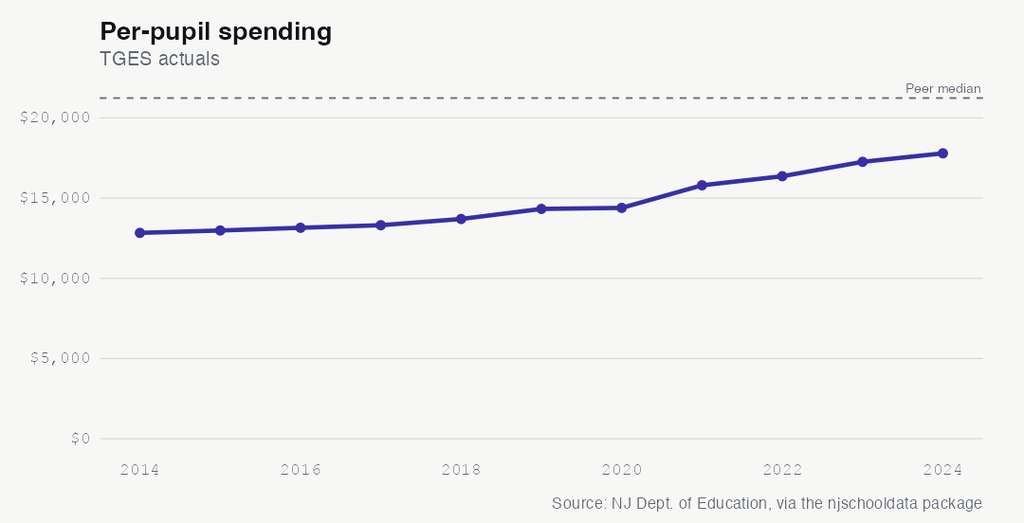

See the underlying data ›

No. 5 EQUITY

## West Windsor-Plainsboro Graduates 97% of Asian and White Students — but 74.7% of Students With Disabilities

In the 2025 cohort, the four-year graduation rate ranged from 100% for multiracial students to 74.7% for students with disabilities.

West Windsor-Plainsboro’s 2025 four-year graduation rate of 96.5% sits near the top across the whole student body, but the figure masks sharp differences by subgroup. Students who are Asian graduated at 97.4% and students who are white at 97.0%, while students with disabilities graduated at 74.7% — a gap of more than 22 percentage points within the same district.

Other subgroups fell between those poles. Students who are Black graduated at 86.1%, students who are Hispanic at 90.0%, students who are economically disadvantaged at 90.2%, and multilingual learners at 86.7%. The largest single subgroup, students who are Asian, made up 572 of the 794-student cohort, while students with disabilities numbered 79 and students who are Black numbered 36.

In a district where the overall rate clears 96%, the open question is why outcomes for students with disabilities trail the majority by more than 20 points — and what supports would close it.

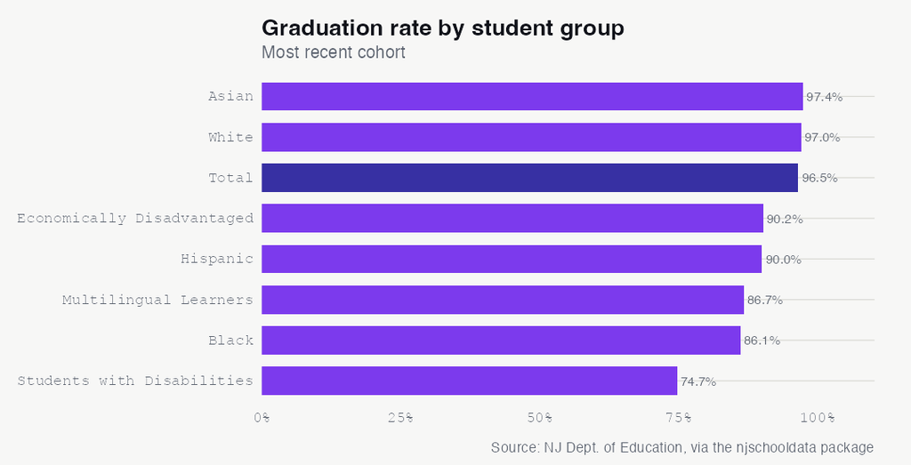

See the underlying data ›

No. 6 ATTENDANCE

## Chronic Absenteeism in West Windsor-Plainsboro Hit 8.6% in 2024 — Above the 5.8% Peer Median

After spiking to 11.8% in 2023, the share of students who are chronically absent eased to 8.6% but still ran above its affluent peer group and its own pre-pandemic level.

Before the pandemic, West Windsor-Plainsboro had little trouble keeping students in their seats: 5.5% of students were chronically absent in 2019. The picture changed sharply afterward. After dropping to 1.5% in the remote-learning year of 2021, chronic absenteeism climbed to 7.8% in 2022 and peaked at 11.8% in 2023 before easing to 8.6% in 2024.

That 2024 rate remained above two reference points: the district’s own 5.5% pre-COVID baseline, and the 5.8% median for its District Factor Group J peers. For a district with strong test and graduation outcomes, attendance is a metric that has not yet returned to its earlier footing — and the same years that saw attendance falter also saw elementary reading scores slide.

The data shows a recovery underway but incomplete. Whether the 2024 decline marks a return to pre-pandemic norms or a new, higher plateau is the question the next year of data will answer.

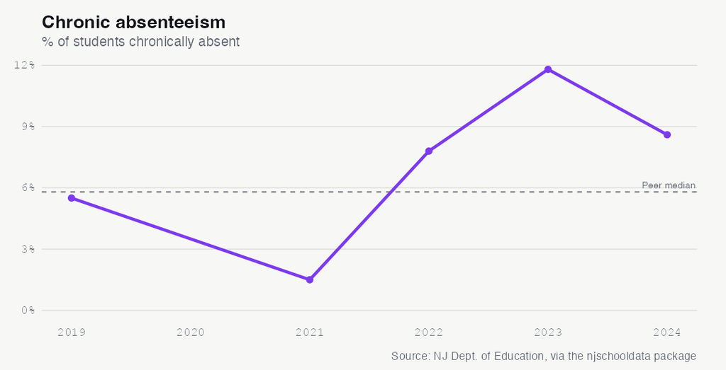

See the underlying data ›

No. 7 EQUITY

## Economic Need in West Windsor-Plainsboro More Than Doubled: Free-Lunch Eligibility Rose From 4.9% to 10.8%

The number of students eligible for free or reduced-price lunch grew from 473 in 2015 to 941 in 2026, even as total enrollment fell.

West Windsor-Plainsboro is known as one of New Jersey’s most affluent districts, and most of its students still fall outside the free-lunch program. But the share who qualify has more than doubled. Free or reduced-price lunch eligibility rose from 4.9% of students in 2015 to 10.8% in 2026, with the headcount climbing from 473 students to 941 even as overall enrollment shrank.

The sharpest jump came recently: eligibility stood at 6.4% in 2024 before rising to 9.1% in 2025 and 10.8% in 2026. Over the same window, the number of students classified as multilingual learners grew from 237 (2.5%) in 2015 to 496 (5.7%) in 2026, a parallel sign of a shifting student population.

See the underlying data ›

No. 8 ENROLLMENT

## West Windsor-Plainsboro Enrollment Falls to a Record-Low 8,708 — Down 918 Since 2015

The district shed nearly one in ten students over 11 years, with more than half the loss concentrated around the pandemic.

The pandemic accelerated an already-emerging decline. Between 2019 and 2022 the district lost 539 students, a 5.6% drop, with the steepest single-year falls coming in 2021 (down 225) and 2022 (down 269). The losses have continued more gently since, with declines of 115 in 2025 and 101 in 2026.

Fewer students reshape everything from staffing to budgets to building use. The question the enrollment data raises is whether this is a temporary post-pandemic dip or the start of a longer demographic contraction.

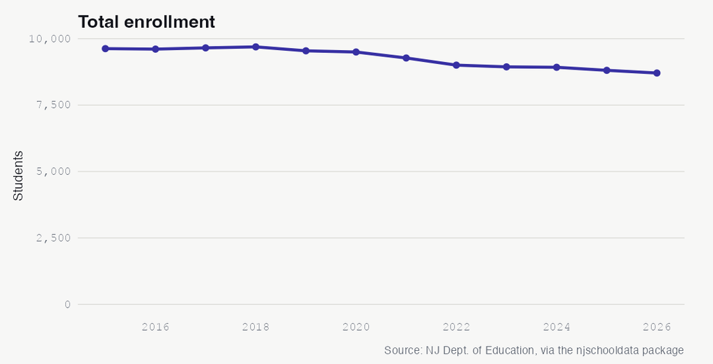

See the underlying data ›

No. 9 GRADUATION

## West Windsor-Plainsboro’s 96.5% Graduation Rate Ranks Near the Bottom of Its 25 Affluent Peers

A rate that would lead most districts puts West Windsor-Plainsboro in the 18th percentile of its District Factor Group J peer group, where the median is 98.2%.

West Windsor-Plainsboro graduated 96.5% of its 2025 four-year cohort, a figure that exceeds most New Jersey districts. But against its own peer group it lands low: the rate ranks in the 18th percentile among the 25 districts in District Factor Group J, where the median graduation rate is 98.2%.

The district’s rate has drifted down modestly in recent years, from 97.7% in 2020 and 97.8% in 2022 to 96.5% in 2025. Within an elite peer group where rates cluster tightly near the ceiling, even small differences move a district’s rank, and the subgroup gaps that pull the average down — students with disabilities at 74.7%, students who are Black at 86.1% — are visible in the same data.

The data poses a question of standards rather than crisis: in a peer group where nearly everyone graduates, what separates a 96.5% from a 98.2%?

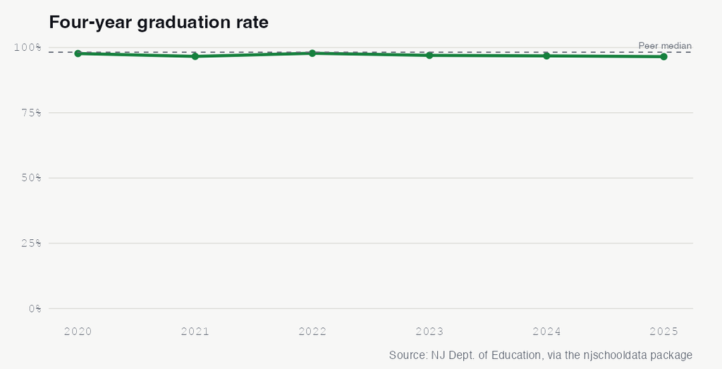

See the underlying data ›

No. 10 COLLEGE READINESS

## 64% of West Windsor-Plainsboro Students Pass an AP or IB Exam, Up From 52.7% in 2018

Advanced coursework is not a niche pursuit in West Windsor-Plainsboro — it is closer to the norm, and it is growing. In 2024, 64.0% of the district’s students scored a 3 or higher on an Advanced Placement exam or a 4 or higher on an International Baccalaureate exam, up from 52.7% in 2018. The reach of the program is unusually broad: 84.2% of students took AP or IB coursework in 2024 and 69.4% sat for an exam, so the passing rate reflects most of the student body clearing a college-credit bar rather than a small honors cohort.

The climb has been mostly steady, from 52.7% in 2018 to 58.8% in 2019, dipping to 55.0% in 2021 during pandemic disruptions before recovering to 60.1% in 2023 and reaching 64.0% in 2024. Coursework participation jumped notably in the most recent year, from 79.0% in 2023 to 84.2% in 2024.

The contrast with the district’s elementary picture is striking: as high-school AP and IB success has risen, NJSLA reading proficiency in grades 3 through 8 has fallen to 74.0%. The data raises a question about the pipeline — whether the strength at the top of the system will hold as the cohorts now testing lower in the lower grades move up.

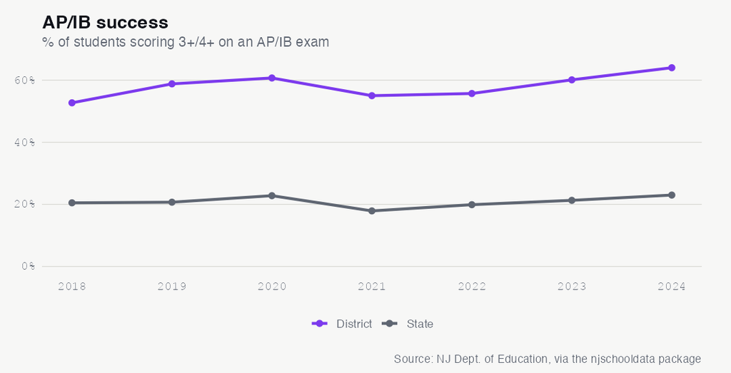

See the underlying data ›

## The Almanac

The full longitudinal record behind the stories above. Every number a reader can check.

### Enrollment (total)

| year | students | yoy | yoy_pct |
| --- | --- | --- | --- |
| 2015 | 9626 | NA | NA |
| 2016 | 9608 | -18 | -0.2 |
| 2017 | 9654 | 46 | 0.5 |
| 2018 | 9692 | 38 | 0.4 |
| 2019 | 9544 | -148 | -1.5 |
| 2020 | 9499 | -45 | -0.5 |
| 2021 | 9274 | -225 | -2.4 |
| 2022 | 9005 | -269 | -2.9 |
| 2023 | 8940 | -65 | -0.7 |
| 2024 | 8924 | -16 | -0.2 |
| 2025 | 8809 | -115 | -1.3 |
| 2026 | 8708 | -101 | -1.1 |

### Demographic share (%) by year

| end_year | white | black | hispanic | asian | native_american | pacific_islander | multiracial |
| --- | --- | --- | --- | --- | --- | --- | --- |
| 2015 | 26.7 | 5.7 | 4.6 | 61.9 | 0 | 0.1 | 1.1 |
| 2016 | 24 | 5.4 | 4.3 | 65 | 0.1 | 0.1 | 1.2 |
| 2017 | 22 | 5 | 4.5 | 67.1 | 0 | 0.1 | 1.3 |
| 2018 | 19.9 | 5.1 | 4.6 | 69.1 | 0 | 0.1 | 1.2 |
| 2019 | 18.8 | 4.8 | 4.3 | 70.5 | 0 | 0.1 | 1.4 |
| 2020 | 17.7 | 4.7 | 4.2 | 71.6 | 0.1 | 0.1 | 1.6 |
| 2021 | 16.2 | 4.9 | 4.7 | 71.8 | 0.1 | 0.1 | 2.2 |
| 2022 | 14.9 | 5 | 5.1 | 72.1 | 0.2 | 0.1 | 2.7 |
| 2023 | 13.6 | 5.1 | 5.5 | 72.3 | 0.2 | 0.1 | 3.2 |
| 2024 | 12.8 | 5.1 | 5.2 | 72.9 | 0.3 | 0.1 | 3.7 |
| 2025 | 12.3 | 4.9 | 5.5 | 72.5 | 0.4 | 0.1 | 4.3 |
| 2026 | 11.8 | 5.1 | 6 | 71.9 | 0.4 | 0 | 4.7 |

### Special populations (LEP, FRL)

| end_year | subgroup | students | pct |
| --- | --- | --- | --- |
| 2015 | lep | 237 | 2.5 |
| 2015 | free_reduced_lunch | 473 | 4.9 |
| 2016 | lep | 241 | 2.5 |
| 2016 | free_reduced_lunch | 522 | 5.4 |
| 2017 | lep | 262 | 2.7 |
| 2017 | free_reduced_lunch | 501 | 5.2 |
| 2018 | lep | 326 | 3.4 |
| 2018 | free_reduced_lunch | 489 | 5.0 |
| 2019 | lep | 268 | 2.8 |
| 2019 | free_reduced_lunch | 474 | 5.0 |
| 2020 | lep | 313 | 3.3 |
| 2020 | free_reduced_lunch | 456 | 4.8 |
| 2021 | lep | 343 | 3.7 |
| 2021 | free_reduced_lunch | 454 | 4.9 |
| 2022 | lep | 297 | 3.3 |
| 2022 | free_reduced_lunch | 531 | 5.9 |
| 2023 | lep | 322 | 3.6 |
| 2023 | free_reduced_lunch | 501 | 5.6 |
| 2024 | lep | 348 | 3.9 |
| 2024 | free_reduced_lunch | 571 | 6.4 |
| 2025 | lep | 449 | 5.1 |
| 2025 | free_reduced_lunch | 802 | 9.1 |
| 2026 | lep | 496 | 5.7 |
| 2026 | free_reduced_lunch | 941 | 10.8 |

### Graduation rate 4yr (total)

| year | grad_rate | cohort |
| --- | --- | --- |
| 2020 | 97.7 | 731 |
| 2021 | 96.6 | 812 |
| 2022 | 97.8 | 805 |
| 2023 | 97 | 829 |
| 2024 | 96.8 | 793 |
| 2025 | 96.5 | 794 |

### Graduation by subgroup (2025)

| subgroup | grad_rate | cohort |
| --- | --- | --- |
| multiracial | 100.0 | 13 |
| asian | 97.4 | 572 |
| white | 97.0 | 133 |
| female | 96.7 | 389 |
| total | 96.5 | 794 |
| male | 96.3 | 405 |
| economically disadvantaged | 90.2 | 92 |
| hispanic | 90.0 | 40 |
| multilingual learners | 86.7 | 15 |
| black | 86.1 | 36 |
| students with disabilities | 74.7 | 79 |
| american indian | NA | NA |
| migrant students | NA | NA |
| military-connected students | NA | NA |
| non-binary/undesignated gender | NA | NA |
| students experiencing homelessness | NA | NA |
| students in foster care | NA | NA |

### NJGPA high-school proficiency (% proficient+)

| year | test | prof_above | valid |
| --- | --- | --- | --- |
| 2023 | ela | NA | NA |
| 2023 | math | NA | NA |
| 2024 | ela | NA | NA |
| 2024 | math | NA | NA |
| 2025 | ela | NA | NA |
| 2025 | math | 88.8 | 778 |

### NJGPA ELA by subgroup (2025)

[output not shown]

### NJSLA grades 3-8 proficiency (% proficient+, enrollment-weighted across grades)

| testing_year | test_name | prof |
| --- | --- | --- |
| 2017 | ela | 82.3 |
| 2017 | math | 75.1 |
| 2018 | math | 74.7 |
| 2019 | ela | 80.4 |
| 2019 | math | 75.1 |
| 2022 | ela | 75.5 |
| 2022 | math | 64.9 |
| 2023 | ela | 77.5 |
| 2023 | math | 66.9 |
| 2024 | ela | 74.0 |
| 2024 | math | 67.4 |

### NJSLA ELA proficiency by subgroup (2024, grades 3-8)

| subgroup | prof |
| --- | --- |
| asian | 81.5 |
| female | 78.9 |
| non_ed | 76.7 |
| total_population | 74.0 |
| male | 69.7 |
| other | 65.2 |
| lep_former | 64.3 |
| FORMER - ML | 61.3 |
| white | 56.4 |
| MULTILINGUAL LEARNERS | 43.5 |
| hispanic | 41.8 |
| lep_current_former | 41.3 |
| black | 36.8 |
| ed | 30.3 |
| special_education | 19.4 |
| sped_accomodations | 14.3 |
| CURRENT - ML | 3.2 |
| lep_current | 0.0 |

### Chronic absenteeism (% chronically absent)

| year | chronic_pct |
| --- | --- |
| 2019 | 5.5 |
| 2021 | 1.5 |
| 2022 | 7.8 |
| 2023 | 11.8 |
| 2024 | 8.6 |

### Disciplinary removals

[output not shown]

### Police notifications (incident counts)

| year | violence | weapons | vandalism | substances | hib | other |
| --- | --- | --- | --- | --- | --- | --- |
| 2019 | 3 | 2 | 6 | 17 | 3 | 0 |
| 2020 | 10 | 2 | 3 | 4 | 8 | 0 |
| 2021 | 1 | 0 | 0 | 1 | 2 | 0 |
| 2022 | 13 | 3 | 6 | 7 | 1 | 0 |
| 2023 | 3 | 1 | 1 | 10 | 2 | 2 |
| 2024 | 1 | 6 | 0 | 3 | 1 | 1 |

### HIB (harassment/intimidation/bullying) investigations

| end_year | alleged | confirmed |
| --- | --- | --- |
| 2019 | 67 | 89 |
| 2020 | 57 | 70 |
| 2021 | 13 | 34 |
| 2022 | 94 | 139 |
| 2023 | 178 | 252 |
| 2024 | 61 | 139 |

### SAT participation (% of grade)

| year | sat_part | state_sat |
| --- | --- | --- |
| 2018 | 87.1 | 72.2 |
| 2019 | 87.4 | 72.1 |
| 2020 | 93.2 | 71.1 |
| 2021 | 86.1 | 45.4 |
| 2022 | 84.9 | 60.8 |
| 2023 | 87.3 | 61.9 |
| 2024 | 87.5 | 62.7 |

### AP/IB & dual enrollment (% of students)

| year | apib_coursework | apib_exam | ap3_ib4 | state_ap3_ib4 | dual |
| --- | --- | --- | --- | --- | --- |
| 2018 | 78.9 | 56.1 | 52.7 | 20.5 | 0 |
| 2019 | 79.5 | 62.4 | 58.8 | 20.7 | 0 |
| 2020 | 78.3 | 64.4 | 60.7 | 22.8 | 0 |
| 2021 | 79.6 | 64.3 | 55 | 17.9 | 0 |
| 2022 | 76.8 | 63.5 | 55.7 | 19.9 | 0 |
| 2023 | 79 | 65.4 | 60.1 | 21.3 | 0 |
| 2024 | 84.2 | 69.4 | 64 | 23 | 0 |

### Special education (raw rows; inspect for classification rate)

| end_year | district_id |
| --- | --- |
| 2024 | 5715 |

### Per-pupil spending (TGES actuals)

| year | per_pupil | rank | ade |
| --- | --- | --- | --- |
| 2014 | 12833 | 25 | 9719 |
| 2015 | 12982 | 22 | 9706 |
| 2016 | 13151 | 22 | 9619 |
| 2017 | 13311 | 16 | 9668 |
| 2018 | 13699 | 16 | 9702 |
| 2019 | 14327 | 16 | 9556 |
| 2020 | 14391 | 17 | 9526 |
| 2021 | 15799 | 35 | 9294 |
| 2022 | 16365 | 34 | 9033 |
| 2023 | 17262 | 34 | 8988 |
| 2024 | 17792 | 28 | 8948 |

### Spending composition shares (2025)

| classroom_share | support_services_share | administration_share | plant_ops_share | food_service_share | extracurricular_share | equipment_share |
| --- | --- | --- | --- | --- | --- | --- |
| 59.4 | 15.8 | 9.7 | 12.5 | NA | 2.3 | 0 |

### Staffing ratios

| end_year | student_teacher_district | student_admin_district | student_counselor_district | student_nurse_district |
| --- | --- | --- | --- | --- |
| 2024 | 11:1 | 174:1 | 265:1 | 531:1 |

Back to top